# Lab 1 - Intro to R and RStudio

Hari Karne

Feb 7 2017

**Load Arbuthnot’s data:**

```r
source("http://www.openintro.org/stat/data/arbuthnot.R")
```

#### Exercise 1:

```r
# code for Exercise 1 is already entered below as an example

library(dplyr)
library(ggplot2)

arbuthnot$girls
```

```
##  [1] 4683 4457 4102 4590 4839 4820 4928 4605 4457 4952 4784 5332 5200 4910
## [15] 4617 3997 3919 3395 3536 3181 2746 2722 2840 2908 2959 3179 3349 3382
## [29] 3289 3013 2781 3247 4107 4803 4881 5681 4858 4319 5322 5560 5829 5719
## [43] 6061 6120 5822 5738 5717 5847 6203 6033 6041 6299 6533 6744 7158 7127
## [57] 7246 7119 7214 7101 7167 7302 7392 7316 7483 6647 6713 7229 7767 7626
## [71] 7452 7061 7514 7656 7683 5738 7779 7417 7687 7623 7380 7288
```

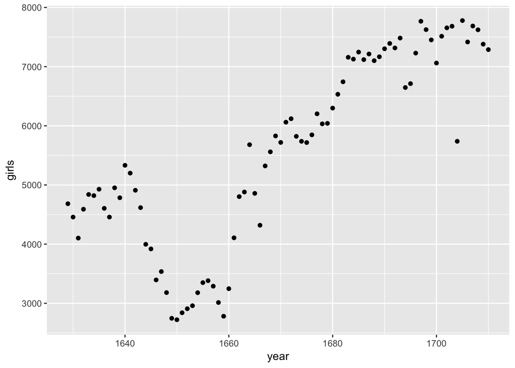

```r
qplot(x = year, y = girls, data = arbuthnot)
```

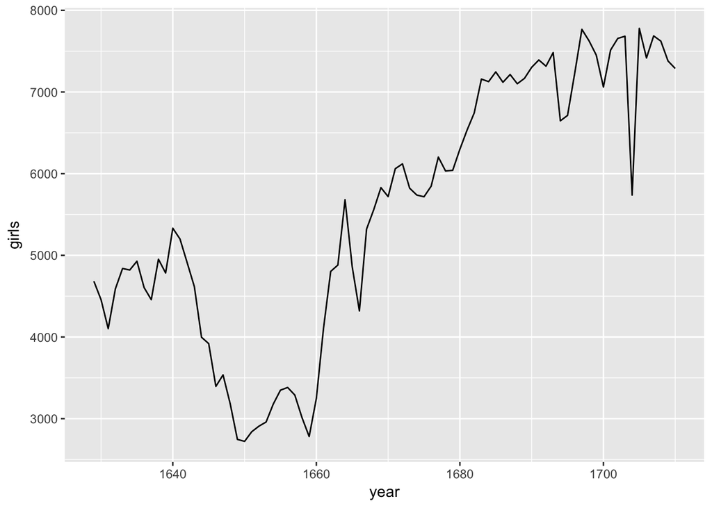

```r
qplot(x = year, y = girls, data = arbuthnot, geom = "line")
```

#### Exercise 2:

The number of girls baptized increased from about 4600 to 7600 from the years 1620 to 1720. There was a large dip in baptisms between 1650 and 1660, and a sharp dip around 1705.

```r
5218 + 4683
```

```
## [1] 9901
```

```r
arbuthnot$boys + arbuthnot$girls
```

```
##  [1]  9901  9315  8524  9584  9997  9855 10034  9522  9160 10311 10150
## [12] 10850 10670 10370  9410  8104  7966  7163  7332  6544  5825  5612
## [23]  6071  6128  6155  6620  7004  7050  6685  6170  5990  6971  8855
## [34] 10019 10292 11722  9972  8997 10938 11633 12335 11997 12510 12563
## [45] 11895 11851 11775 12399 12626 12601 12288 12847 13355 13653 14735
## [56] 14702 14730 14694 14951 14588 14771 15211 15054 14918 15159 13632
## [67] 13976 14861 15829 16052 15363 14639 15616 15687 15448 11851 16145
## [78] 15369 16066 15862 15220 14928
```

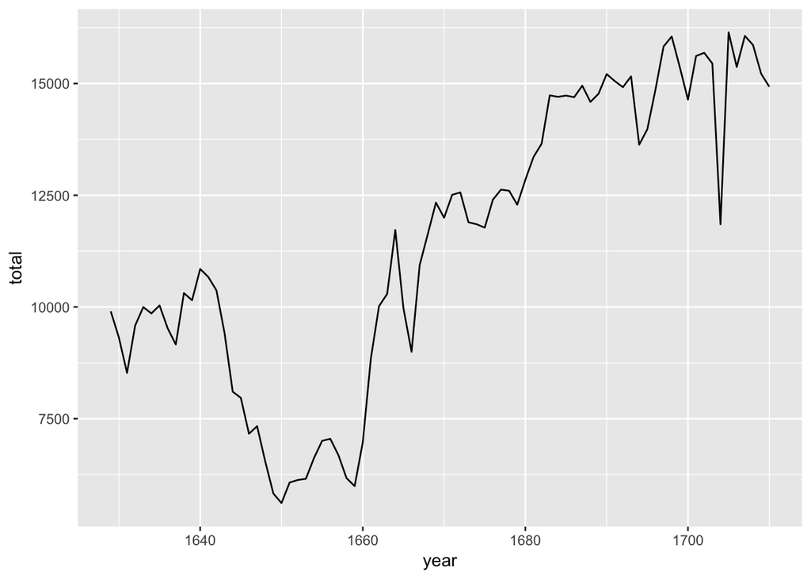

```r
arbuthnot <- arbuthnot %>%
  mutate(total = boys + girls)
qplot(x = year, y = total, data = arbuthnot, geom = "line")
```

```r
5218 / 4683
```

```
## [1] 1.114243
```

```r
arbuthnot <- arbuthnot %>%
  mutate(boy_to_girl_ratio = boys / girls)

5218 / (5218 + 4683)
```

```
## [1] 0.5270175
```

```r
arbuthnot <- arbuthnot %>%
  mutate(boy_ratio = boys / total)
```

#### Exercise 3:

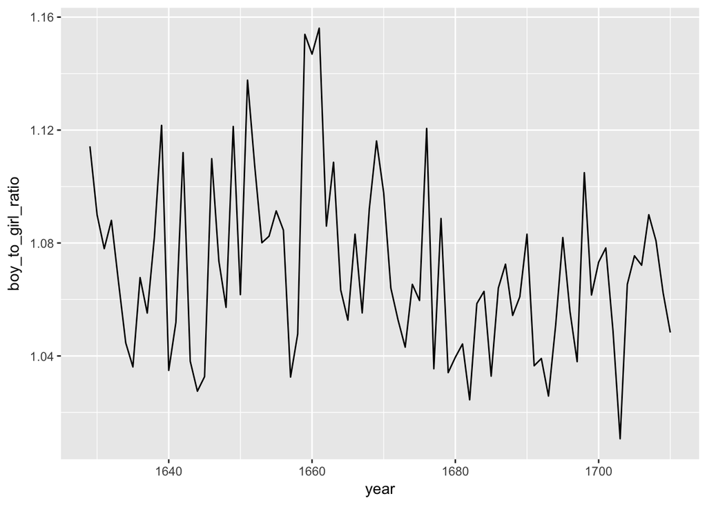

```r
qplot(x = year, y = boy_to_girl_ratio , data = arbuthnot, geom = "line")
```

```r
arbuthnot <- arbuthnot %>%
  mutate(more_boys = boys > girls)
```

### On your own:

**Load present day data:**

```r
source("http://www.openintro.org/stat/data/present.R")
```

#### 1: There are 63 years and 3 variables in the data set. The years go from 1940 - 2002, and the three variables are: year, boys, girls.

```r
dim(present)
```

```
## [1] 63  3
```

```r
names(present)
```

```
## [1] "year"  "boys"  "girls"
```

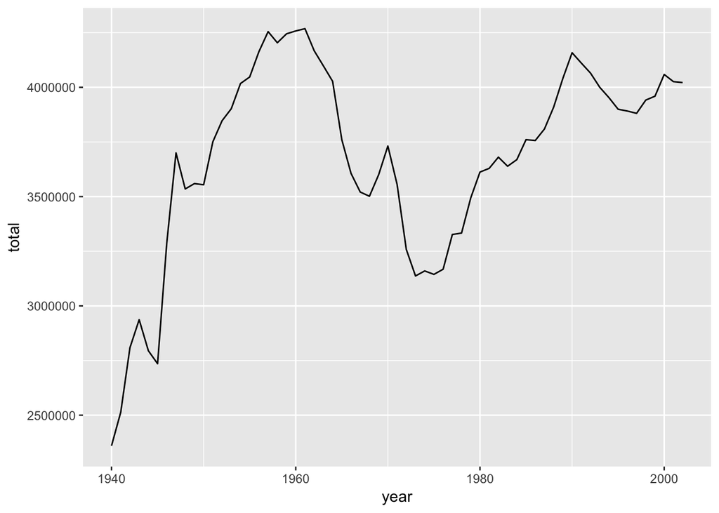

```r
present <- present %>%
  mutate(total = boys + girls)
qplot(x = year, y = total, data = present, geom = "line")
```

#### 3: The overall boy to girl ratio from Dr. Arbuthnot’s data is higher than the present day boy to girl ratio. The present day boy to girl ratio has been slowly decreasing, but is still slightly above 1, which means that more boys than girls are born every year. This supports Dr. Arbuthnot’s obeservation that boys are born in greater proportion than girls.

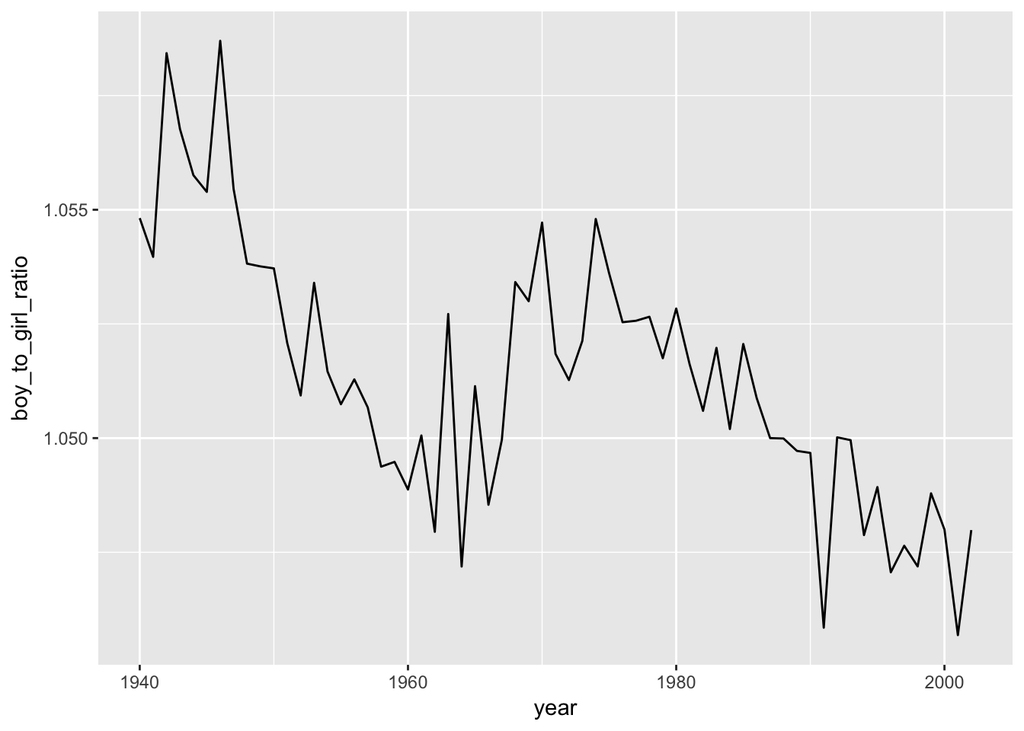

```r
present <- present %>%
  mutate(boy_to_girl_ratio = boys / girls)
qplot(x = year, y = boy_to_girl_ratio , data = present, geom = "line")
```

#### 4: 1961 had the greatest total number of births with 4,268,326 children born.

```r
present <- present %>%
  mutate(total = boys + girls)

present %>%
  arrange(desc(total))
```

```
##    year    boys   girls   total boy_to_girl_ratio
## 1  1961 2186274 2082052 4268326          1.050057
## 2  1960 2179708 2078142 4257850          1.048873
## 3  1957 2179960 2074824 4254784          1.050672
## 4  1959 2173638 2071158 4244796          1.049480
## 5  1958 2152546 2051266 4203812          1.049374
## 6  1962 2132466 2034896 4167362          1.047948
## 7  1956 2133588 2029502 4163090          1.051286
## 8  1990 2129495 2028717 4158212          1.049676
## 9  1991 2101518 2009389 4110907          1.045849
## 10 1963 2101632 1996388 4098020          1.052717
## 11 1992 2082097 1982917 4065014          1.050017
## 12 2000 2076969 1981845 4058814          1.047998
## 13 1955 2073719 1973576 4047295          1.050742
## 14 1989 2069490 1971468 4040958          1.049720
```

[output cut: 49 more lines]